# Homework 2

FINM 33210: Bayesian Statistical Inference and Machine Learning

Ki Hyun

Due: 23:59 (CT) April 29th 2023

```r
library(dplyr)
library(purrr)
library(glmnet)
library(ggplot2)
```

## Problem 2.2

### (a)

```r
coordinate_descent <- function(lambda, y, X){
  # constants
  n <- nrow(X)
  p <- ncol(X)
  # scaling constants
  ## mean values
  y_center <- mean(y)
  X_center <- colMeans(X)
  ## standard deviations
  y_scale <- sd(y)
  X_scale <- apply(X, 2, sd)
  # scaling y and X
  X <- scale(X)
  y <- scale(y)
  # speedup suggested by 2.20
  yX <- crossprod(y, X)
  oneX <- rep(0, times = p) # since X is scaled
  XX <- crossprod(X)
  # speedup for gamma calculation
  X_square_norm <- diag(XX)
  gamma <- n * lambda / X_square_norm
  # remainder of 2.20
  diag(XX) <- 0
  # initial arbitrary guess for betas
  updated_betas <- betas <- rep(0, times = (p + 1))
  # from 2.19
  updated_betas[1] <- 0.0 # with scaled data, beta 0 is constantly 0
  # tolerance to define "not meaningful change"
  tol <- 1e-10
  while(TRUE){
    for(i in 1:p){
      # from 2.17
      zx <- yX[i] - updated_betas[1] * oneX[i] -t(updated_betas[-1]) %*% XX[,i]
      beta_hat <- zx / X_square_norm[i]
      # from 2.18
      updated_betas[i+1] <- sign(beta_hat) * max(c(0, abs(beta_hat) - gamma[i]))
    }
    # checking convergence based on threshold
    if(max(abs(updated_betas - betas)) < tol){
      break
    }
    # save the updated values to betas prior to construction
    betas <- updated_betas
  }
  # back to unscaled coefficients:
  betas[-1] <- updated_betas[-1] * y_scale / X_scale
  # from 2.19
  betas[1] <- y_center - X_center %*% betas[-1]
  return(betas)
}
```

```r
LASSO <- function(lambdas, y, X){
  map_dfr(lambdas, ~set_names(c(., coordinate_descent(., y, X)),
                              c("Lambda" ,"(Intercept)",
                                paste0("X", seq_along(X)))))
}
```

### (b)

We may generate the data based on the given formula:

$$y = 3x_1 - 17x_2 + 5x_3 + \epsilon, \
\epsilon \sim N(0, 1)$$

For the $X_1$, $X_2$, and $X_3$, I will use `Sepal Length`, `Sepal Width`, and `Petal Length` (respectively) from the `iris` data-set.

```r
# generating X data
data("iris")
X <- iris[1:3]
# basic dimensions of data
n <- nrow(X)
p <- ncol(X)
colnames(X) <- map_chr(1:p, ~paste0("X", .))
# setting random seed
set.seed(5581)
# producing error
epsilon <- rnorm(n)
# producing y data
coeffs <- c(3, -17, 5)
y <- as.matrix(X) %*% coeffs + epsilon
```

The generated data is shown below:

```r
cbind(y, X)
```

| y | X1 | X2 | X3 |
| --- | --- | --- | --- |
| -39.1177565 | 5.1 | 3.5 | 1.4 |
| -29.4723773 | 4.9 | 3.0 | 1.4 |
| -34.8723787 | 4.7 | 3.2 | 1.3 |
| -30.5003511 | 4.6 | 3.1 | 1.5 |
| -37.5605425 | 5.0 | 3.6 | 1.4 |
| -40.6138219 | 5.4 | 3.9 | 1.7 |
| -37.7974650 | 4.6 | 3.4 | 1.4 |
| -34.6899642 | 5.0 | 3.4 | 1.5 |
| -26.5454566 | 4.4 | 2.9 | 1.4 |
| -32.7807388 | 4.9 | 3.1 | 1.5 |

[output cut: 140 more lines]

Now from the coded function in `2.2 (a)`, we may compute the LASSO solution path for 100 $\lambda$ values. We may do the same using the `glmnet` package in `R`.

```r
lambdas <- 10^seq(-3, 5, length.out = 100)
glm_fit <- glmnet(as.matrix(X), y, lambda = lambdas, standardize = TRUE,
                  alpha = 1) #alpha is set to 1 in order to be a LASSO
LASSO_fit <- LASSO(lambdas, y, X)
```

Below are the results from the `glmnet` package:

```r
as.matrix(coef(glm_fit)) %>%
  t(.) %>%
  cbind(., "Lambda" = glm_fit$lambda) %>%
  as_tibble(.) %>%
  select(5, 1:4) %>%
  arrange(Lambda)
```

| Lambda | (Intercept) | X1 | X2 | X3 |
| --- | --- | --- | --- | --- |
| 1.000000e-03 | -1.3796955 | 2.9277993 | -16.5500734 | 5.1286743 |
| 1.204504e-03 | -1.3766772 | 2.9257729 | -16.5482947 | 5.1295748 |
| 1.450829e-03 | -1.3733700 | 2.9235244 | -16.5462967 | 5.1305657 |
| 1.747528e-03 | -1.3697646 | 2.9210371 | -16.5440564 | 5.1316511 |
| 2.104904e-03 | -1.3658566 | 2.9182956 | -16.5415493 | 5.1328343 |
| 2.535364e-03 | -1.3616499 | 2.9152863 | -16.5387495 | 5.1341164 |
| 3.053856e-03 | -1.3571585 | 2.9119983 | -16.5356305 | 5.1354962 |
| 3.678380e-03 | -1.3524110 | 2.9084255 | -16.5321649 | 5.1369688 |
| 4.430621e-03 | -1.3474548 | 2.9045680 | -16.5283259 | 5.1385248 |
| 5.336699e-03 | -1.3423618 | 2.9004347 | -16.5240876 | 5.1401483 |

[output cut: 90 more lines]

Below are the results from the function in `2.2 (a)`:

```r
LASSO_fit %>%
  arrange(Lambda)
```

| Lambda | (Intercept) | X1 | X2 | X3 |
| --- | --- | --- | --- | --- |
| 1.000000e-03 | -1.377024132 | 2.9077729 | -16.5169045 | 5.1321180 |
| 1.204504e-03 | -1.371277796 | 2.9003745 | -16.5073829 | 5.1343463 |
| 1.450829e-03 | -1.364356314 | 2.8914631 | -16.4959141 | 5.1370304 |
| 1.747528e-03 | -1.356019364 | 2.8807293 | -16.4820998 | 5.1402633 |
| 2.104904e-03 | -1.345977479 | 2.8678005 | -16.4654605 | 5.1441574 |
| 2.535364e-03 | -1.333881992 | 2.8522276 | -16.4454184 | 5.1488478 |
| 3.053856e-03 | -1.319312935 | 2.8334700 | -16.4212777 | 5.1544974 |
| 3.678380e-03 | -1.301764455 | 2.8108764 | -16.3922000 | 5.1613024 |
| 4.430621e-03 | -1.280627248 | 2.7836624 | -16.3571759 | 5.1694991 |
| 5.336699e-03 | -1.255167408 | 2.7508830 | -16.3149892 | 5.1793720 |

[output cut: 90 more lines]

Though not precisely the same at the $10^{-10}$ threshold level, the two methods yield a similar result.

## Problem 2.3

### (a)

As a Financial Mathematics student, I felt the urge to set the true $\beta$ values according to the Fibonacci sequence. Since the 50th Fibonacci number is too huge, I will repeat each Fibonacci number (starting from the third) 10 times

$$\beta_1 = 1 \\
\vdots \\
\beta_{10} = 1 \\
\beta_{11} = 2 \\
\vdots \\
\beta_{20} = 2 \\
\vdots \\
\beta_{41} = 8 \\
\vdots \\
\beta_{50} = 8$$

Therefore, the linear model, for $i$th observation, would be in the form:

$$\begin{aligned}
y_i =& x_{1, i} + \cdots + x_{10, i} \\
+& 2 x_{11, i} + \cdots + 2 x_{20, i} \\
+& 3 x_{21, i} + \cdots + 3 x_{30, i} \\
+& 5 x_{31, i} + \cdots + 5 x_{40, i} \\
+& 8 x_{41, i} + \cdots + 8 x_{50, i} \\
+& \epsilon_i
\end{aligned}$$

Here,

$$\epsilon_i \stackrel{\mathrm{iid}}{\sim} \mathcal{N}(0,\sigma^2)$$

For simplicity reasons, I will set $\sigma = 1$.

### (b)

Continuing on from the values set in `(a)`, I will generate $\mathbf{X}$ values using data-sets provided by `R`.

Each of $x_i$ will be derived from the Normal distribution with the mean set as one of the 5 `float` variables in the `mtcars` data-set (i.e., `Miles/Gallon`, `Displacement(cu.in.)`, `Rear Axle Ratio`, `Weight(1000 lbs)`, `Quarter-Mile Time (sec)`). The variance of the normal distribution will be determined by the square of the hundred-fold `Petal Width` observations in the `iris` data-set.

To be precise:

$x_1, \cdots, x_{10}$ will be derived from $N(mpg_1, (100pw_1)^2), \cdots N(mpg_{10}, (100pw_{10})^2)$,

$x_{11}, \cdots, x_{20}$ will be derived from $N(disp_1, (100pw_{11})^2), \cdots N(disp_{10}, (100pw_{20})^2)$,

$x_{21}, \cdots, x_{30}$ will be derived from $N(drat_1, (100pw_{21})^2), \cdots N(drat_{10}, (100pw_{30})^2)$,

$x_{31}, \cdots, x_{40}$ will be derived from $N(wt_1, (100pw_{31})^2), \cdots N(wt_{10}, (100pw_{40})^2)$,

$x_{41}, \cdots, x_{50}$ will be derived from $N(qsec_1, (100pw_{41})^2), \cdots N(qsec_{10}, (100pw_{50})^2)$

```r
data("mtcars")
mus <- c(mtcars$mpg[1:10], mtcars$disp[1:10], mtcars$drat[1:10],
         mtcars$wt[1:10], mtcars$qsec[1:10])
sigmas <- iris$Petal.Width[1:50] * 100
```

```r
set.seed(121)
sets <- 100
n <- 50
betas <- rep(c(1, 2, 3, 5, 8), each = 10)
X <- map2_dfc(mus, sigmas, ~rnorm(sets*n, mean = .x, sd = .y))
colnames(X) <- paste0("X", seq_along(X))
epsilon <- rnorm(sets * n)
y <- as.matrix(X) %*% betas + epsilon
```

Independence condition is already met from generating the data. Nevertheless, I will shuffle and split the generated 5000 observations into 100 training sets, each of size 50.

```r
data <- cbind(y, X)
# shuffle the data
set.seed(5881)
shuffled_data <- data[sample(1:nrow(data)),]
# Split the observations into 100 training sets of size 50 each
train_sets <- split(shuffled_data, rep(1:100, each = 50))
```

### (c)

We will choose the lambdas similar to `Problem 2.2`

```r
lambdas <- 10^seq(-3, 5, length.out = 10000)
```

The mean squared error value for each of 1,000,000 models will be computed.

```r
Lasso_lms <- map(train_sets,
                 ~glmnet(.[-1], .[[1]], lambda = lambdas, standardize = TRUE,
                         #alpha is set to 1 in order to be a LASSO
                         alpha = 1))

errors <- map2_df(train_sets, Lasso_lms,
                  ~apply(predict(.y, newx = as.matrix(.x[-1])) - .x[[1]],
                         2, function (x) mean(x^2))) %>%
  t(.)

colnames(errors) <- paste0("Training set", 1:ncol(errors))

errors <- as_tibble(errors)

mses <- apply(errors, 1, mean)

complexity <- map_df(Lasso_lms, ~.$df)
```

We may also compute the mean squared error across 100 models with the same $\lambda$ values (i.e., models that only vary training sets). Doing so, we are able to create the blue curve below:

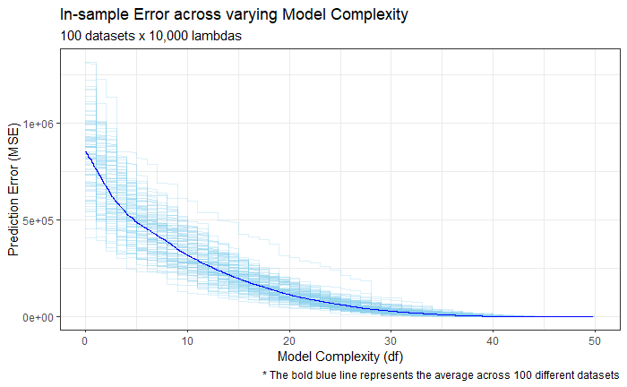

```r
blue_curve <- ggplot()

for(i in 1:sets){
  blue_curve <- blue_curve +
    geom_line(mapping = aes(x = df, y = error),
              data = tibble(df = complexity[[i]], error = errors[[i]]),
              color = "skyblue", alpha = 0.3)
}

blue_curve  +
  geom_line(mapping = aes(x = df, y = error),
            data = tibble(df = rowMeans(complexity), error = mses),
            color = "blue") +
  labs(x = "Model Complexity (df)", y = "Prediction Error (MSE)",
       title = "In-sample Error across varying Model Complexity",
       subtitle = "100 datasets x 10,000 lambdas",
       caption = paste0("* The bold blue line represents the average across ",
                    "100 different datasets")) +
  theme_bw()
```

The error for large lambda / small degrees of freedom are quite huge to to the monotonicity of the true linear model and the scale of the regressors.

### (d)

Let’s first generate a large out-of-sample pairs.

I will create the out-of-sample $\mathbf{X}'$ values by first ordering the original $\mathbf{X}$ so that for each column the smaller values go at the top.

Moreover, I will take the average of adjacent rows for each column so that I have 4,999 new observations for all 50 variables.

Additionally, I will add a last row that takes 2 times the average deducted by the original largest value to match 5,000 observations.

Lastly, I will reorder each of the columns to the original random order of $\mathbf{X}$ to finalize our out-of-sample independent variables data.

```r
# sorting the original data
X_prime = apply(X, 2, sort)
# saving the last row
last_row <- X_prime[nrow(X_prime),]
# get the average of two adjacent rows
X_prime <- (X_prime[1:(nrow(X_prime) - 1),] + X_prime[2:nrow(X_prime),])/2
# compute the last row
last_row <- 2*X_prime[nrow(X_prime),] - last_row
X_prime <- rbind(X_prime, last_row)
# reordering back to original data
original_order <- apply(X, 2, order)
for(col in 1:ncol(X)){
  X_prime[,col] <- X_prime[original_order[,col], col]
}
```

Now with the new $\mathbf{X}'$, we can generate the new $\mathbf{y}'$ as well using the “true” coefficients and newly sampled errors under a new random seed.

```r
set.seed(81)
epsilon_prime <- rnorm(sets * n)
y_prime <- X_prime %*% betas + epsilon_prime
```

Now for each of the 1,000,000 models, the out of sample error can be computed and the variance of the error across 5000 prediction can also be computed

```r
errors_variance <- map_df(Lasso_lms,
                          ~ apply((predict(., newx = as.matrix(X_prime)) -
                                    as.vector(y_prime)),
                                  MARGIN = 2, FUN = var)) %>%
  t(.)
```

A preview of the error variance for 5 lambdas and 5 training datasets can be seen below

| Training set1 | Training set2 | Training set3 | Training set4 | Training set5 |
| --- | --- | --- | --- | --- |
| 888784.4 | 888784.4 | 888784.4 | 888784.4 | 888784.4 |
| 888784.4 | 888784.4 | 888784.4 | 888784.4 | 888784.4 |
| 888784.4 | 888784.4 | 888784.4 | 888784.4 | 888784.4 |
| 888784.4 | 888784.4 | 888784.4 | 888784.4 | 888784.4 |
| 888784.4 | 888784.4 | 888784.4 | 888784.4 | 888784.4 |

Now if we average across the 100-training-set models for the same $\lambda$ the top 10 average prediction error variance can be shown as

| Lambdas | Error Variance |
| --- | --- |
| 100000.00 | 888784.4 |
| 99815.94 | 888784.4 |
| 99632.23 | 888784.4 |
| 99448.85 | 888784.4 |
| 99265.81 | 888784.4 |
| 99083.10 | 888784.4 |
| 98900.74 | 888784.4 |
| 98718.70 | 888784.4 |
| 98537.01 | 888784.4 |
| 98355.64 | 888784.4 |

If we create a similar visualization to that of (c) it becomes:

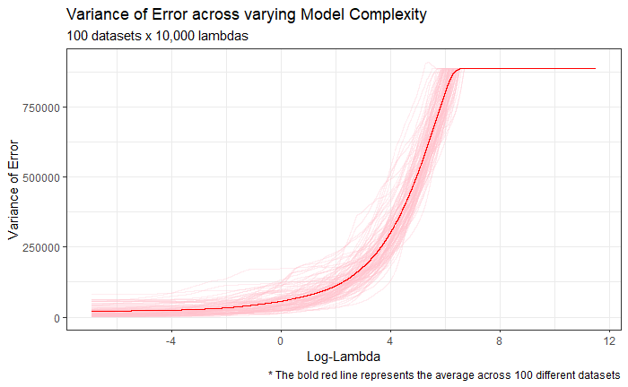

```r
log_lamdas <- log(Lasso_lms[[1]]$lambda)
red_curve <- ggplot()

for(i in 1:sets){
  red_curve <- red_curve +
    geom_line(mapping = aes(x = log_lambda, y = var),
              data = tibble(log_lambda = log_lamdas,
                            var = errors_variance[[i]]),
              color = "pink", alpha = 0.3)
}

red_curve  +
  geom_line(mapping = aes(x = log_lambda, y = var),
            data = tibble(log_lambda = log_lamdas,
                          var = rowMeans(errors_variance)),
            color = "red") +
  labs(x = "Log-Lambda", y = "Variance of Error",
       title = "Variance of Error across varying Model Complexity",
       subtitle = "100 datasets x 10,000 lambdas",
       caption = paste0("* The bold red line represents the average across ",
                    "100 different datasets")) +
  theme_bw()
```